# Reproducible Research: Peer Assessment 1

> Please note that R scripts requires below packages to run
- ggplot2
- scales
- Hmisc

> **Please, install any missing package prior running R code**

> For correct exectution the data file activity.zip must be in the directory from which R code is started. The script will verify the existence of unzipped content and unpack the data if required.

> activity.zip can be downloaded from https://d396qusza40orc.cloudfront.net/repdata%2Fdata%2Factivity.zip

> **Ensure data file is available prior running any R code**

## Loading the data

##### 1. Load the data (i.e. read.csv())

```r
if(!file.exists('activity.csv')){
    unzip('activity.zip')
}
activityData <- read.csv('activity.csv')
```

## QUESTION 1: What is mean total number of steps taken per day?

##### 1. Calculate steps per each day excluding NA values

```r
stepsPerDay <- aggregate(steps ~ as.Date(activityData$date, format = "%Y-%m-%d"), activityData, sum)
colnames(stepsPerDay) <- c("date","steps")
```

##### 2. Make a histogram of the total number of steps taken each day

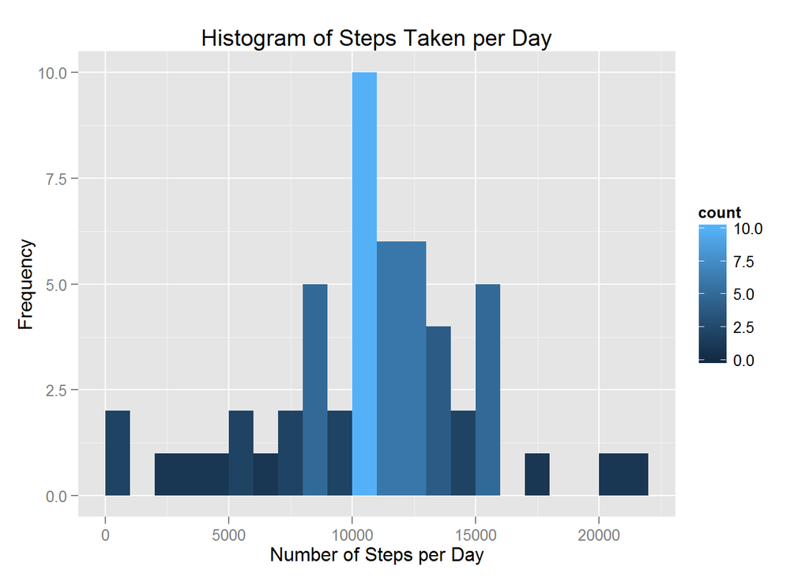

```r
ggplot(stepsPerDay, aes(x = steps)) +
       geom_histogram(aes(fill = ..count..), origin=0.1, binwidth=1000) +
       labs(title="Histogram of Steps Taken per Day",
       x = "Number of Steps per Day", y = "Frequency")
```

##### 3. Calculate and report the mean and median total number of steps taken per day

###### Apply mean and median functions to stepsPerDay

```r
stepsPerDayMean <- mean(stepsPerDay$steps, na.rm=TRUE)
stepsPerDayMedian <- median(stepsPerDay$steps, na.rm=TRUE)
```

## Result

- Mean: 10766.189
- Median: 10765

## QUESTION 2: What is the average daily activity pattern?

##### 1. Calculate average steps per interval

```r
averageStepsPerInterval <- aggregate(x=list(meanSteps=activityData$steps), by=list(interval=activityData$interval), FUN=mean, na.rm=TRUE)
```

##### 2. Create a time series plot

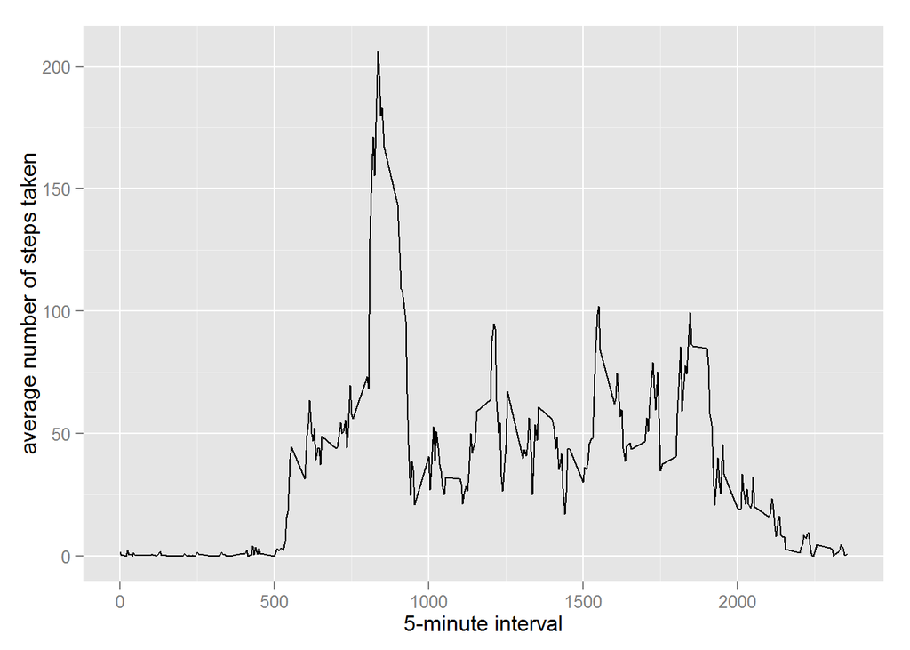

```r
ggplot(data=averageStepsPerInterval, aes(x=interval, y=meanSteps)) +
    geom_line() +
    xlab("5-minute interval") +
    ylab("average number of steps taken")
```

##### 3. Which 5-minute interval, on average across all the days in the dataset, contains the maximum number of steps?

```r
mostSteps <- which.max(averageStepsPerInterval$meanSteps)
timeMostSteps <-  gsub("([0-9]{1,2})([0-9]{2})", "\\1:\\2", averageStepsPerInterval[mostSteps,'interval'])
```

- Most Steps occurred at: 8:35

## QUESTION 3: Imputing missing values

##### 1. Calculate and report the total number of missing values in the dataset

```r
numMissingValues <- length(which(is.na(activityData$steps)))
```

- Number of missing values: 2304

##### 2. Devise a strategy for filling in all of the missing values in the dataset.

###### Missing values will be evaluated using the calculated mean value.

##### 3. Create a new dataset that is equal to the original dataset but with the missing data filled in.

```r
activityDataImputed <- activityData
activityDataImputed$steps <- impute(activityData$steps, fun=mean)
```

##### 4. Make a histogram of the total number of steps taken each day and Calculate and report the mean and median total number of steps taken per day.

###### Plot Histogram:

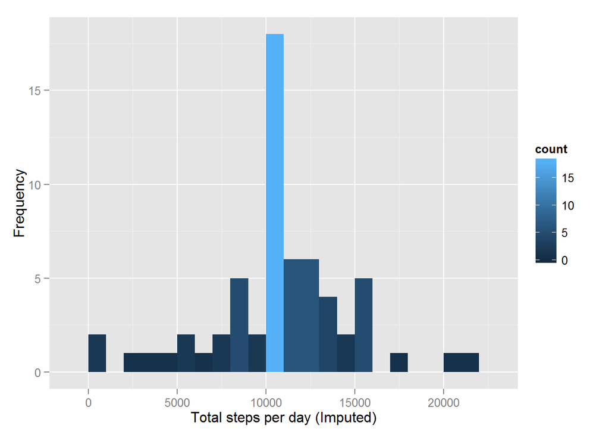

```r
stepsPerDayImputed <- tapply(activityDataImputed$steps, activityDataImputed$date, sum)
qplot(stepsPerDayImputed, xlab='Total steps per day (Imputed)', ylab='Frequency', binwidth=1000) + geom_histogram(aes(fill = ..count..), binwidth=1000)
```

###### Calculate mean and median total number of steps taken per day.:

```r
stepsPerDayMeanImputed <- mean(stepsPerDayImputed)
stepsPerDayMedianImputed <- median(stepsPerDayImputed)
```

- Mean (Imputed): 10766.189
- Median (Imputed): 10766.189

## QUESTION 4: Are there differences in activity patterns between weekdays and weekends?

##### 1. Create a new factor variable in the dataset with two levels - “weekday” and “weekend” indicating whether a given date is a weekday or weekend day.

```r
activityDataImputed$dateType <-  ifelse(as.POSIXlt(activityDataImputed$date)$wday %in% c(0,6), 'weekend', 'weekday')
```

##### 2. Make a panel plot containing a time series plot

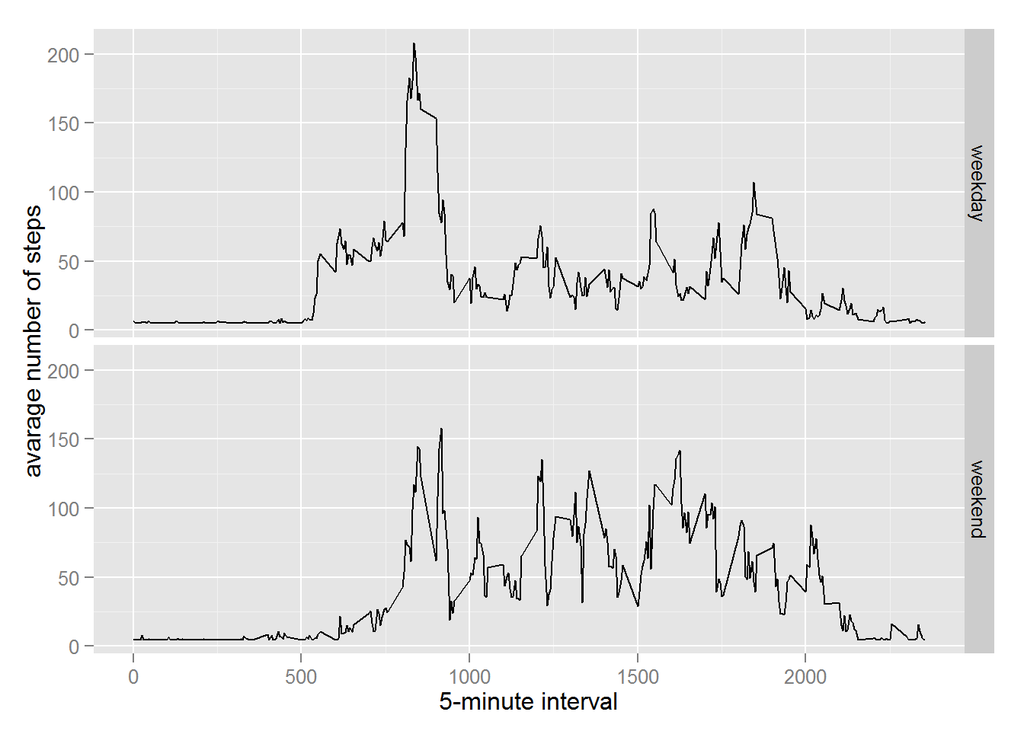

```r
averagedActivityDataImputed <- aggregate(steps ~ interval + dateType, data=activityDataImputed, mean)
ggplot(averagedActivityDataImputed, aes(interval, steps)) +
    geom_line() +
    facet_grid(dateType ~ .) +
    xlab("5-minute interval") +
    ylab("avarage number of steps")
```